# Case Study 2

Robert Burigo

4/11/2021

```r
knitr::opts_chunk$set(fig.path='Figs/')
```

Presentation Slides: Find Here https://github.com/rob-burigo/CaseStudy2DDS

Youtube Presentation: https://www.youtube.com/watch?v=zrN4GN6Uqyw

Github Website: https://rob-burigo.github.io/

## Introduction to the Study

The main goal of this project is explore what characteristics in an employee have the biggest impact on employee retention and also are we then able to predict with good accuracy what employees are likely to turn over. As a bonus, we will also try and see if we can predict Monthly Salary based on the characteristics provided.

We have been given a data set with 36 Variables and 870 observations. This data set contains employee Id’s that are tied to relative characteristics like Age, Years at the company , Distance to the Office, etc.

First, we are going to explore the data set to see if there is anything interesting we can find with a top-level investigation. Next, we will use this data set to train a KNN model and test that KNN model on the validation set provided trying to get both a sensitivity and specificity of over 60%.

Lastly, we will build a regression model to predict the monthly salary for the validation set provided and try and get within $3,000 RMSE.

## Executive Summary

Top 3 most important factors when predicting attrition are * Number of Companies that the employee has worked at in their career * The number of years they have spent in their current role * How satisfied they are with their jobs * Age is close fourth We can take this data and use it in our hiring practices by keeping an eye on how long someones resume is while also using it in employee retention by monitoring HR surveys for Job Satisfaction.

Regarding job role specific findings, it was discovered that Manager is the role with the highest median salary while Manager and Research Director are positions where Employees stay the longest.

Using EDA and KNN classification model, we are able to predict with decent accuracy whether an employee will leave the company or not. We were also able to use multiple linear regression to predict the salary of an employee. * This can help us save money in on-boarding (decreasing attrition) as well as become more competitive in our salary offers.

## Read in Data and Libraries Needed

```r
## Read in libraries and Data
library(tidyverse)
library(naniar)
library(GGally)
library(knitr)
library(kableExtra)
library(class)
library(caret)
library(e1071)
library(mltools)
library(ROSE)
library(MASS)
library(scales)

jobs = read.csv(file.choose(), header = TRUE)
```

## Summary Statistics

```r
#data types and null/missing data
missing_df <- left_join(
(setNames(cbind(rownames(data.frame(data_type = unlist(map(jobs, class))))
, data.frame(data_type = unlist(map(jobs, class))), row.names = NULL),
c("variable", "data_type"))),miss_var_summary(jobs),
by=c("variable"="variable"))%>%arrange(desc(n_miss))




jobs1_n <- (jobs[, sapply(jobs, class) != "character"])
jobs1_c <- (jobs[, sapply(jobs, class) == "character"])
jobs1_c_names <- names(jobs1_c)

mean = sapply(jobs, mean, na.rm = T)


#median & quartiles
median_df <- (setNames(cbind(rownames(data.frame(t(data.frame(sapply(jobs1_n, quantile, na.rm = T)))))
,data.frame(t(data.frame(sapply(jobs1_n, quantile, na.rm = T)))) , row.names = NULL),
c("variable", "Min","Q1","Median","Q3","Max")))

median_df$variable <- gsub('\\.', '-', median_df$variable)


#mean_df
mean_df <- (setNames(cbind(rownames(data.frame(data_type = mean ))
, data.frame(data_type = mean), row.names = NULL),
c("variable", "Mean")))

mean_df$variable <- gsub('\\.', '-', mean_df$variable)



jobs1_c_distinct <- rbind(
data.frame(Variable = jobs1_c_names[1],Levels = unlist(jobs1_c[,1], use.names=FALSE))%>%distinct(Variable,Levels),
data.frame(Variable = jobs1_c_names[2],Levels = unlist(jobs1_c[,2], use.names=FALSE))%>%distinct(Variable,Levels),
data.frame(Variable = jobs1_c_names[3],Levels = unlist(jobs1_c[,3], use.names=FALSE))%>%distinct(Variable,Levels),
data.frame(Variable = jobs1_c_names[4],Levels = unlist(jobs1_c[,4], use.names=FALSE))%>%distinct(Variable,Levels),
data.frame(Variable = jobs1_c_names[5],Levels = unlist(jobs1_c[,5], use.names=FALSE))%>%distinct(Variable,Levels),
data.frame(Variable = jobs1_c_names[6],Levels = unlist(jobs1_c[,6], use.names=FALSE))%>%distinct(Variable,Levels),
data.frame(Variable = jobs1_c_names[7],Levels = unlist(jobs1_c[,7], use.names=FALSE))%>%distinct(Variable,Levels),
data.frame(Variable = jobs1_c_names[8],Levels = unlist(jobs1_c[,8], use.names=FALSE))%>%distinct(Variable,Levels),
data.frame(Variable = jobs1_c_names[9],Levels = unlist(jobs1_c[,9], use.names=FALSE))%>%distinct(Variable,Levels)
)

jobs1_c_distinct2 <- jobs1_c_distinct%>%group_by(Variable)%>%summarize(Count_of_Levels = n())


#final summary
left_join(
left_join(
left_join(missing_df,mean_df,
 by=c("variable"="variable")), median_df,
  by=c("variable"="variable")),jobs1_c_distinct2,
by=c("variable"="Variable"))%>%dplyr::select(
variable,data_type,count_missing=n_miss,`Percent Missing (1.00 = 1%)`=pct_miss,Count_of_Levels,Mean,Median,Min,Q1,Q3,Max) %>%
  kbl() %>%
  kable_classic_2(full_width = F)%>%
  add_header_above(c("Summary Statistics of Data" = 11))
```

| Summary Statistics of Data variable | Summary Statistics of Data data_type | Summary Statistics of Data count_missing | Summary Statistics of Data Percent Missing (1.00 = 1%) | Summary Statistics of Data Count_of_Levels | Summary Statistics of Data Mean | Summary Statistics of Data Median | Summary Statistics of Data Min | Summary Statistics of Data Q1 | Summary Statistics of Data Q3 | Summary Statistics of Data Max |
| --- | --- | --- | --- | --- | --- | --- | --- | --- | --- | --- |
| ID | integer | 0 | 0 | NA | 435.500000 | 435.5 | 1 | 218.25 | 652.75 | 870 |
| Age | integer | 0 | 0 | NA | 36.828736 | 35.0 | 18 | 30.00 | 43.00 | 60 |
| Attrition | character | 0 | 0 | 2 | NA | NA | NA | NA | NA | NA |
| BusinessTravel | character | 0 | 0 | 3 | NA | NA | NA | NA | NA | NA |
| DailyRate | integer | 0 | 0 | NA | 815.227586 | 817.5 | 103 | 472.50 | 1165.75 | 1499 |
| Department | character | 0 | 0 | 3 | NA | NA | NA | NA | NA | NA |
| DistanceFromHome | integer | 0 | 0 | NA | 9.339080 | 7.0 | 1 | 2.00 | 14.00 | 29 |
| Education | integer | 0 | 0 | NA | 2.901149 | 3.0 | 1 | 2.00 | 4.00 | 5 |
| EducationField | character | 0 | 0 | 6 | NA | NA | NA | NA | NA | NA |
| EmployeeCount | integer | 0 | 0 | NA | 1.000000 | 1.0 | 1 | 1.00 | 1.00 | 1 |
| EmployeeNumber | integer | 0 | 0 | NA | 1029.832184 | 1039.0 | 1 | 477.25 | 1561.50 | 2064 |
| EnvironmentSatisfaction | integer | 0 | 0 | NA | 2.701149 | 3.0 | 1 | 2.00 | 4.00 | 4 |
| Gender | character | 0 | 0 | 2 | NA | NA | NA | NA | NA | NA |
| HourlyRate | integer | 0 | 0 | NA | 65.613793 | 66.0 | 30 | 48.00 | 83.00 | 100 |
| JobInvolvement | integer | 0 | 0 | NA | 2.722989 | 3.0 | 1 | 2.00 | 3.00 | 4 |
| JobLevel | integer | 0 | 0 | NA | 2.039080 | 2.0 | 1 | 1.00 | 3.00 | 5 |
| JobRole | character | 0 | 0 | 9 | NA | NA | NA | NA | NA | NA |
| JobSatisfaction | integer | 0 | 0 | NA | 2.709195 | 3.0 | 1 | 2.00 | 4.00 | 4 |
| MaritalStatus | character | 0 | 0 | 3 | NA | NA | NA | NA | NA | NA |
| MonthlyIncome | integer | 0 | 0 | NA | 6390.264368 | 4945.5 | 1081 | 2839.50 | 8182.00 | 19999 |
| MonthlyRate | integer | 0 | 0 | NA | 14325.620690 | 14074.5 | 2094 | 8092.00 | 20456.25 | 26997 |
| NumCompaniesWorked | integer | 0 | 0 | NA | 2.727586 | 2.0 | 0 | 1.00 | 4.00 | 9 |
| Over18 | character | 0 | 0 | 1 | NA | NA | NA | NA | NA | NA |
| OverTime | character | 0 | 0 | 2 | NA | NA | NA | NA | NA | NA |
| PercentSalaryHike | integer | 0 | 0 | NA | 15.200000 | 14.0 | 11 | 12.00 | 18.00 | 25 |
| PerformanceRating | integer | 0 | 0 | NA | 3.151724 | 3.0 | 3 | 3.00 | 3.00 | 4 |
| RelationshipSatisfaction | integer | 0 | 0 | NA | 2.706897 | 3.0 | 1 | 2.00 | 4.00 | 4 |
| StandardHours | integer | 0 | 0 | NA | 80.000000 | 80.0 | 80 | 80.00 | 80.00 | 80 |
| StockOptionLevel | integer | 0 | 0 | NA | 0.783908 | 1.0 | 0 | 0.00 | 1.00 | 3 |
| TotalWorkingYears | integer | 0 | 0 | NA | 11.052874 | 10.0 | 0 | 6.00 | 15.00 | 40 |
| TrainingTimesLastYear | integer | 0 | 0 | NA | 2.832184 | 3.0 | 0 | 2.00 | 3.00 | 6 |
| WorkLifeBalance | integer | 0 | 0 | NA | 2.781609 | 3.0 | 1 | 2.00 | 3.00 | 4 |
| YearsAtCompany | integer | 0 | 0 | NA | 6.962069 | 5.0 | 0 | 3.00 | 10.00 | 40 |
| YearsInCurrentRole | integer | 0 | 0 | NA | 4.204598 | 3.0 | 0 | 2.00 | 7.00 | 18 |
| YearsSinceLastPromotion | integer | 0 | 0 | NA | 2.168966 | 1.0 | 0 | 0.00 | 3.00 | 15 |
| YearsWithCurrManager | integer | 0 | 0 | NA | 4.140230 | 3.0 | 0 | 2.00 | 7.00 | 17 |

## Variables vs. Attrition

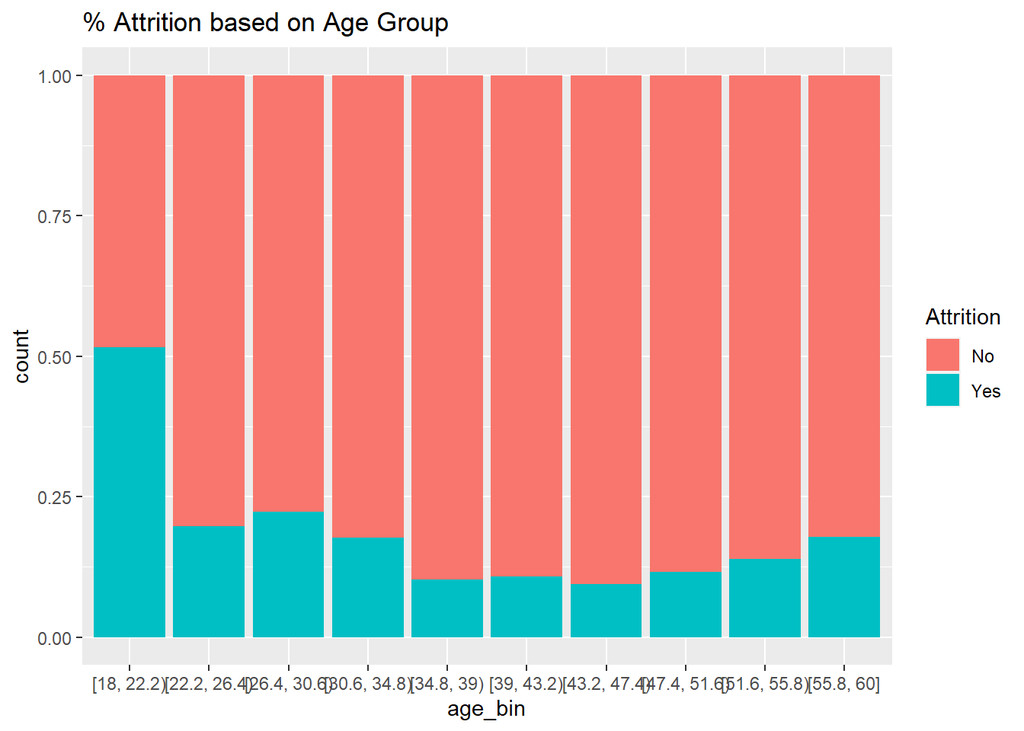

```r
## PLotting the continuous variables first

jobs[, "age_bin"] <- bin_data(jobs$Age, bins=10, binType = "explicit")
ggplot(data=jobs, aes(age_bin))+
  geom_bar(aes(fill=Attrition), position="fill")+ ggtitle('% Attrition based on Age Group')
```

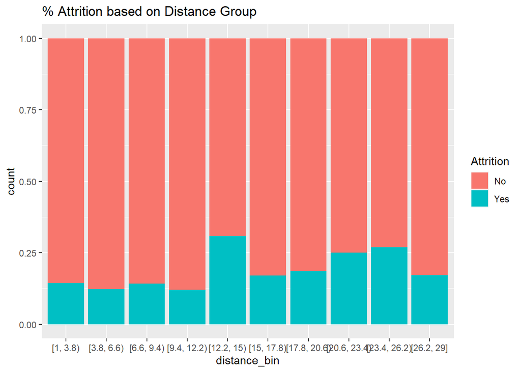

```r
jobs[, "distance_bin"] <- bin_data(jobs$DistanceFromHome, bins=10, binType = "explicit")
ggplot(data=jobs, aes(distance_bin))+
  geom_bar(aes(fill=Attrition), position="fill")+ ggtitle('% Attrition based on Distance Group')
```

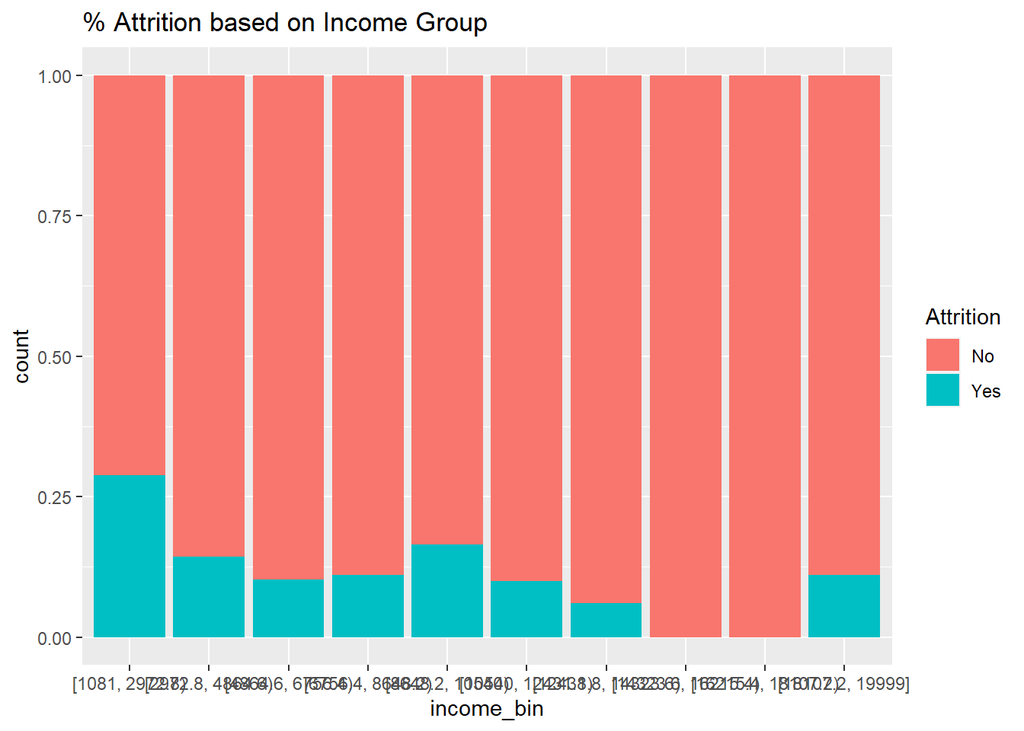

```r
jobs[, "income_bin"] <- bin_data(jobs$MonthlyIncome, bins=10, binType = "explicit")
ggplot(data=jobs, aes(income_bin))+
  geom_bar(aes(fill=Attrition), position="fill")+ ggtitle('% Attrition based on Income Group')
```

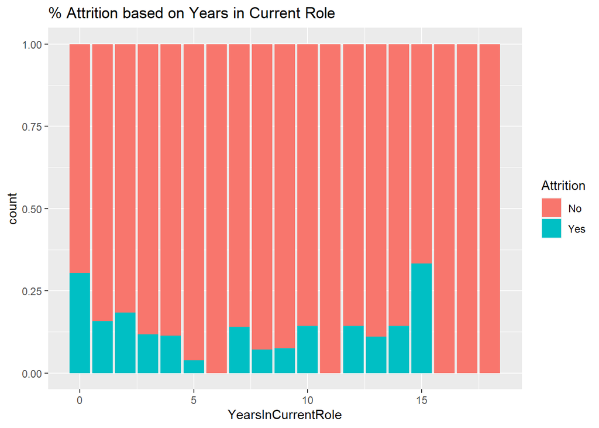

```r
##Plotting the categorical variables now

ggplot(data=jobs, aes(YearsInCurrentRole))+
  geom_bar(aes(fill=Attrition), position="fill")+ ggtitle('% Attrition based on Years in Current Role')
```

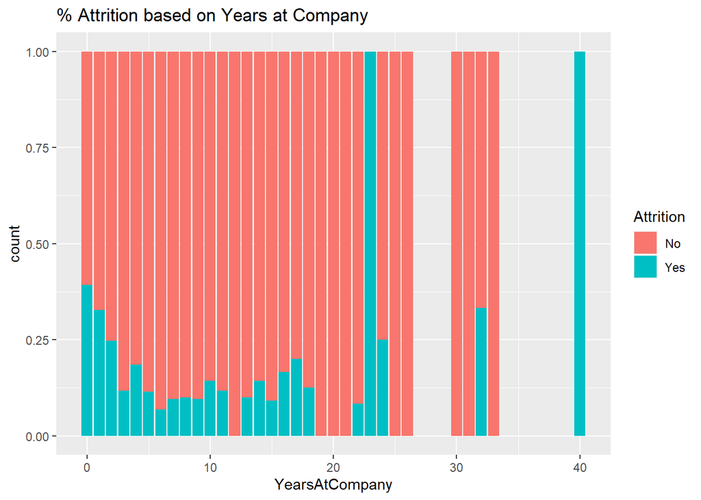

```r
ggplot(data=jobs, aes(YearsAtCompany))+
  geom_bar(aes(fill=Attrition), position="fill")+ ggtitle('% Attrition based on Years at Company')
```

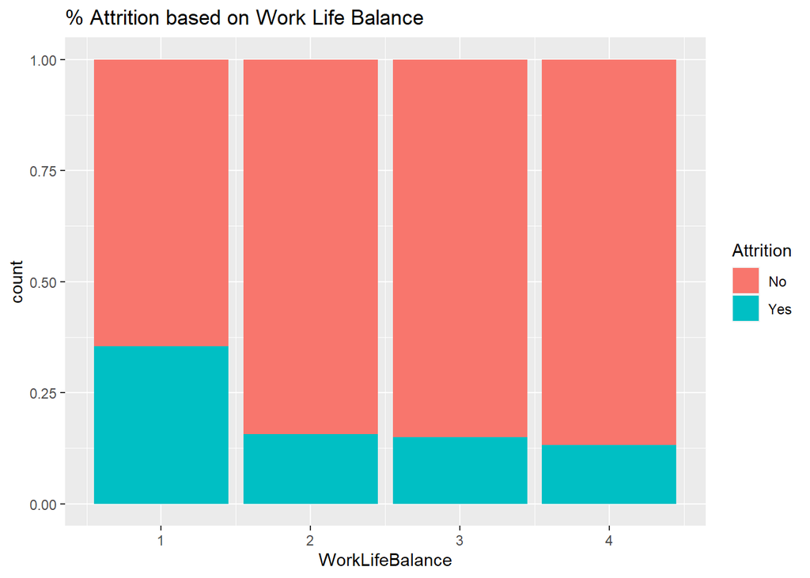

```r
ggplot(data=jobs, aes(WorkLifeBalance))+
  geom_bar(aes(fill=Attrition), position="fill")+ ggtitle('% Attrition based on Work Life Balance')
```

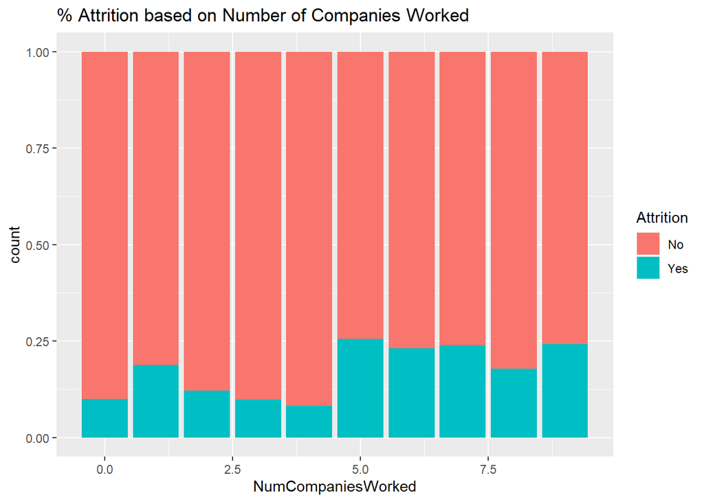

```r
ggplot(data=jobs, aes(NumCompaniesWorked))+
  geom_bar(aes(fill=Attrition), position="fill")+ ggtitle('% Attrition based on Number of Companies Worked')
```

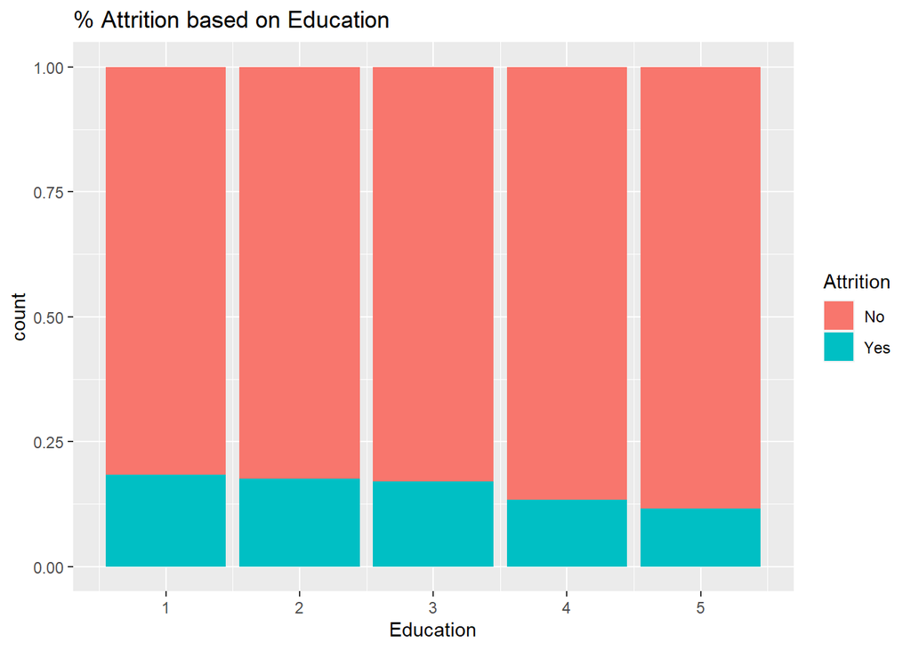

```r
ggplot(data=jobs, aes(Education))+
  geom_bar(aes(fill=Attrition), position="fill")+ ggtitle('% Attrition based on Education')
```

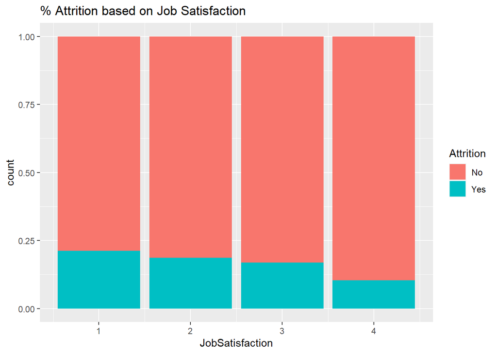

```r
ggplot(data=jobs, aes(JobSatisfaction))+
  geom_bar(aes(fill=Attrition), position="fill")+ ggtitle('% Attrition based on Job Satisfaction')
```

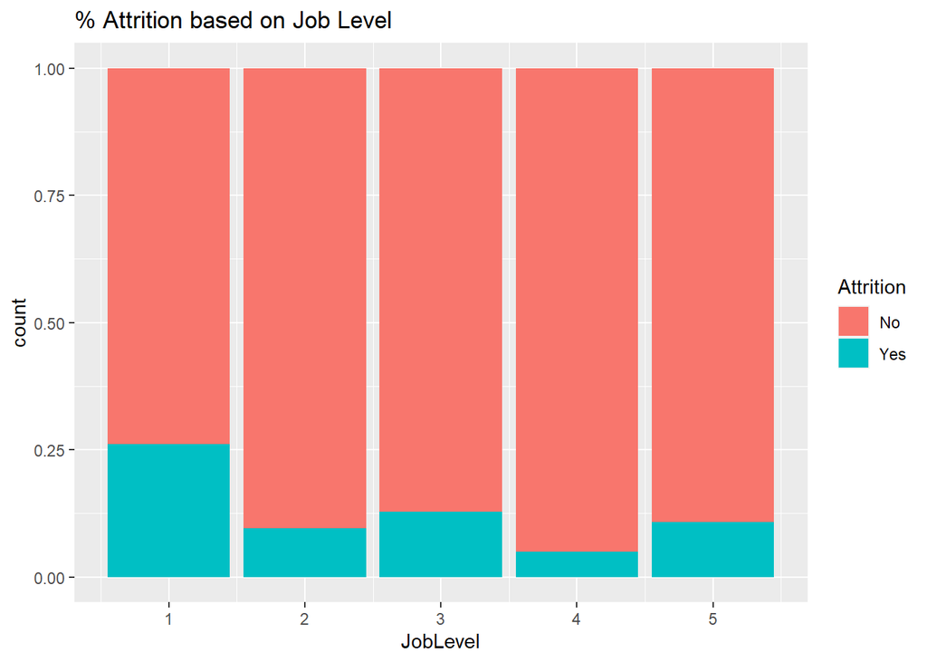

```r
ggplot(data=jobs, aes(JobLevel))+
  geom_bar(aes(fill=Attrition), position="fill")+ ggtitle('% Attrition based on Job Level')
```

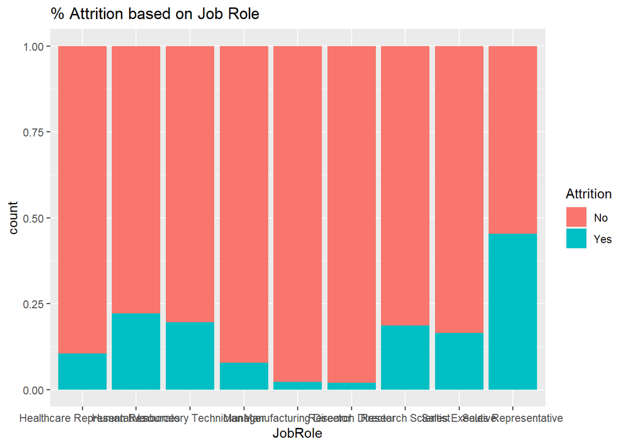

```r
ggplot(data=jobs, aes(JobRole))+
  geom_bar(aes(fill=Attrition), position="fill")+ ggtitle('% Attrition based on Job Role')
```

```r
#Converting Job Role to Numeric So can use in model

jobs = jobs %>%
  mutate(Job_Role_num = case_when(
    jobs$JobRole=='Healthcare Representative' ~ 1,
    jobs$JobRole=='Human Resources' ~ 2,
    jobs$JobRole=='Laboratory Technician' ~ 3,
    jobs$JobRole=='Manager' ~ 4,
    jobs$JobRole=='Manufacturing Director' ~ 5,
    jobs$JobRole=='Research Director' ~ 6,
    jobs$JobRole=='Research Scientist' ~ 7,
    jobs$JobRole=='Sales Executive' ~ 8,
    jobs$JobRole=='Sales Representative' ~ 9
  )
)





#Creating Data frame of Just the variables that seem important
jobs_reduced = jobs[,c(2,3,7,8,16,18,20,22,32,33,34,37,40)]

#Removing Age Bin

drop <- c("age_bin")
jobs_reduced = jobs_reduced[,!(names(jobs_reduced) %in% drop)]

#Converting Yes/No into 1/0
jobs_reduced_cor <- jobs_reduced %>%
      mutate(Attrition = ifelse(Attrition == "No",0,1))
cor(jobs_reduced_cor)
```

```
##                             Age   Attrition DistanceFromHome    Education
## Age                 1.000000000 -0.14938358      0.006647112  0.217290207
## Attrition          -0.149383577  1.00000000      0.087136293 -0.049442357
## DistanceFromHome    0.006647112  0.08713629      1.000000000  0.049512940
## Education           0.217290207 -0.04944236      0.049512940  1.000000000
## JobLevel            0.479423564 -0.16213644      0.021727054  0.130385908
## JobSatisfaction    -0.022363414 -0.10752094     -0.021218476  0.013111079
## MonthlyIncome       0.484288301 -0.15491496     -0.006667155  0.127131394
## NumCompaniesWorked  0.293521877  0.06101889     -0.048909244  0.160918010
## WorkLifeBalance    -0.012229885 -0.08978971     -0.013820292  0.009824289
## YearsAtCompany      0.289538716 -0.12875406     -0.020830094  0.061974487
## YearsInCurrentRole  0.208349696 -0.15621571     -0.008407782  0.061381620
## Job_Role_num       -0.105969885  0.09053860     -0.012799586  0.063075019
##                       JobLevel JobSatisfaction MonthlyIncome NumCompaniesWorked
## Age                 0.47942356    -0.022363414   0.484288301        0.293521877
## Attrition          -0.16213644    -0.107520935  -0.154914955        0.061018887
## DistanceFromHome    0.02172705    -0.021218476  -0.006667155       -0.048909244
## Education           0.13038591     0.013111079   0.127131394        0.160918010
## JobLevel            1.00000000    -0.050306065   0.951640049        0.140834828
## JobSatisfaction    -0.05030606     1.000000000  -0.053148530       -0.075753415
## MonthlyIncome       0.95164005    -0.053148530   1.000000000        0.155894318
## NumCompaniesWorked  0.14083483    -0.075753415   0.155894318        1.000000000
## WorkLifeBalance     0.03028387    -0.026470304   0.020804889        0.021316529
## YearsAtCompany      0.52058351     0.028363964   0.491378966       -0.142025883
## YearsInCurrentRole  0.39130482    -0.003471690   0.361840521       -0.103814233
## Job_Role_num       -0.07429945     0.008906795  -0.075165525       -0.008968013
##                    WorkLifeBalance YearsAtCompany YearsInCurrentRole
## Age                   -0.012229885     0.28953872        0.208349696
## Attrition             -0.089789709    -0.12875406       -0.156215707
## DistanceFromHome      -0.013820292    -0.02083009       -0.008407782
## Education              0.009824289     0.06197449        0.061381620
## JobLevel               0.030283868     0.52058351        0.391304819
## JobSatisfaction       -0.026470304     0.02836396       -0.003471690
## MonthlyIncome          0.020804889     0.49137897        0.361840521
## NumCompaniesWorked     0.021316529    -0.14202588       -0.103814233
## WorkLifeBalance        1.000000000     0.02947258        0.082104934
## YearsAtCompany         0.029472580     1.00000000        0.776116418
## YearsInCurrentRole     0.082104934     0.77611642        1.000000000
## Job_Role_num           0.025982297    -0.09122394       -0.035873768
##                    Job_Role_num
## Age                -0.105969885
## Attrition           0.090538602
## DistanceFromHome   -0.012799586
## Education           0.063075019
## JobLevel           -0.074299446
## JobSatisfaction     0.008906795
## MonthlyIncome      -0.075165525
## NumCompaniesWorked -0.008968013
## WorkLifeBalance     0.025982297
## YearsAtCompany     -0.091223937
## YearsInCurrentRole -0.035873768
## Job_Role_num        1.000000000
```

## Are there any Job Role Specefic Trends

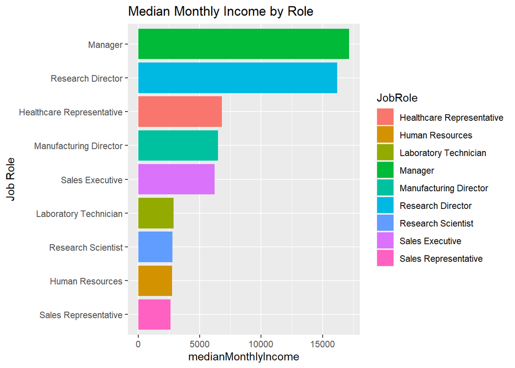

```r
#Get the median monthly income and median years in current role.
median_data = jobs %>% group_by(JobRole) %>% summarize(medianMonthlyIncome = median(MonthlyIncome), medianYearsCurrentRole = median(YearsInCurrentRole))

#created a bar chart comparing the median monthly income per job role
median_data%>%
  head(10)%>%
  ggplot(aes(x=reorder(JobRole,medianMonthlyIncome),y=medianMonthlyIncome, fill=JobRole)) +
  xlab("Job Role")+
  geom_col() + coord_flip() + ggtitle('Median Monthly Income by Role')
```

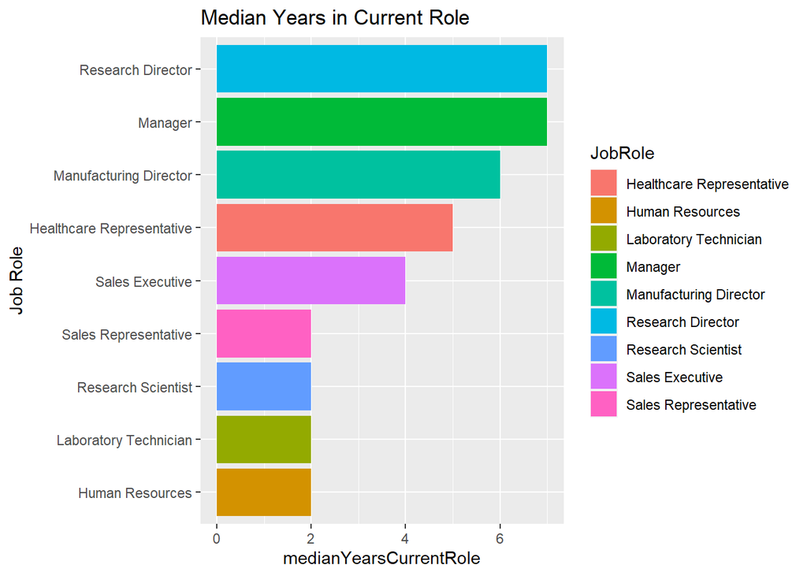

```r
#created a bar chart comparing the median years in current role per job role
median_data%>%
  head(10)%>%
  ggplot(aes(x=reorder(JobRole,medianYearsCurrentRole),y=medianYearsCurrentRole, fill=JobRole)) +
  xlab("Job Role")+
  geom_col() + coord_flip() + ggtitle('Median Years in Current Role')
```

```r
## Manager is the role with the highest median salary

## Manager and Research Director are positions where Employees stay the longest.
```

## Determine Important Features

```r
#Converting Response Variable to a Factor to run Log Reg
jobs_reduced$Attrition = as.factor(jobs_reduced$Attrition)

#Splitting into Train and Test
set.seed(512)
splitPerc = .75

#Running Log Reg and also with a Stepwise to determine important Factors

trainIndices = sample(1:dim(jobs_reduced)[1],round(splitPerc * dim(jobs_reduced)[1]))
train = jobs_reduced[trainIndices,]
test = jobs_reduced[-trainIndices,]

full.logistic<-glm(Attrition~.,family="binomial",data=train)
step.logistic<-full.logistic %>% stepAIC(trace=FALSE)

summary(step.logistic)
```

```
##
## Call:
## glm(formula = Attrition ~ Age + DistanceFromHome + JobSatisfaction +
##     MonthlyIncome + NumCompaniesWorked + WorkLifeBalance + YearsAtCompany +
##     YearsInCurrentRole + Job_Role_num, family = "binomial", data = train)
##
## Deviance Residuals:
##     Min       1Q   Median       3Q      Max
## -1.4684  -0.6068  -0.4568  -0.2795   2.9808
##
## Coefficients:
##                      Estimate Std. Error z value Pr(>|z|)
## (Intercept)         9.763e-01  7.616e-01   1.282 0.199890
## Age                -4.275e-02  1.601e-02  -2.670 0.007578 **
## DistanceFromHome    3.437e-02  1.362e-02   2.523 0.011636 *
## JobSatisfaction    -2.974e-01  1.027e-01  -2.896 0.003774 **
## MonthlyIncome      -9.661e-05  3.999e-05  -2.416 0.015708 *
## NumCompaniesWorked  1.630e-01  4.691e-02   3.474 0.000513 ***
## WorkLifeBalance    -3.784e-01  1.520e-01  -2.489 0.012819 *
## YearsAtCompany      8.305e-02  3.618e-02   2.295 0.021719 *
## YearsInCurrentRole -1.532e-01  5.509e-02  -2.780 0.005433 **
## Job_Role_num        7.819e-02  4.745e-02   1.648 0.099390 .
## ---
## Signif. codes:  0 '***' 0.001 '**' 0.01 '*' 0.05 '.' 0.1 ' ' 1
##
## (Dispersion parameter for binomial family taken to be 1)
##
##     Null deviance: 562.19  on 651  degrees of freedom
## Residual deviance: 503.89  on 642  degrees of freedom
## AIC: 523.89
##
## Number of Fisher Scoring iterations: 5
```

```r
# 3 Most Important factors for Attrition are NumCompaniesWorked , YearsInCurrentRole , JobSatisfaction (Age is a close 4th)
```